# Model Performance Evaluation

Michael Longstreth

April 17, 2018

# Solution Evalution

Per the Formal Problem Statement, we are going to use the average data expansion of of the processing ticket information (“DS1”) received from the CTO group to evaluate performance

## Initial Inspection of Data

### Data Expansion:

#### Outlier Identification

After the prepropcessing script has completed, we need to perform further investigation into the data to identify possible outliers in the data expansion rate.

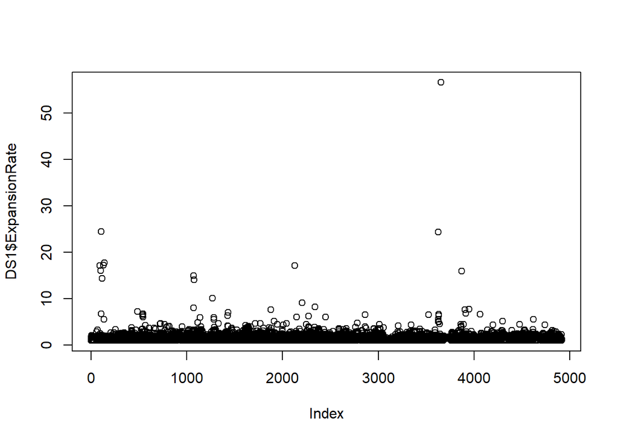

```r
plot(DS1$ExpansionRate)
```

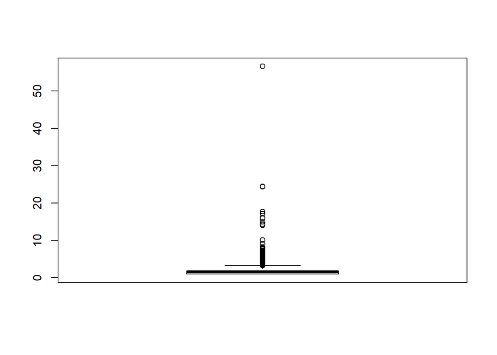

```r
boxplot(DS1$ExpansionRate)
```

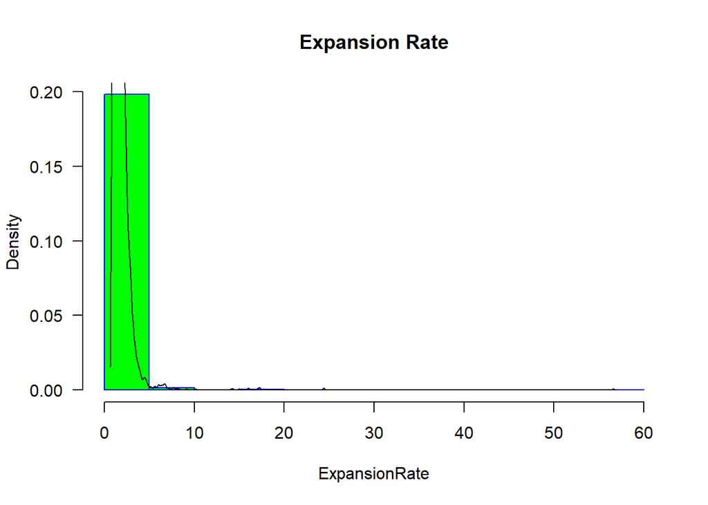

```r
hist(DS1$ExpansionRate,
     main="Expansion Rate",
     xlab="ExpansionRate",
     border="blue",
     col="green",
     las=1,
     prob = TRUE)
lines(density(DS1$ExpansionRate))
```

```r
print(summary(DS1$ExpansionRate))
```

```
##    Min. 1st Qu.  Median    Mean 3rd Qu.    Max.
##   1.000   1.043   1.637   1.726   1.946  56.623
```

#### Trimming Outliers

From the initial investigation into the outliers in data expansion rate from information received from CTO, there appear to be some significant outliers, as the max is 56.623, however, 75% fo the observations are below 1.947. The improve the quality of the analysis, I have determined to create a subset of the data to work with removing the outliers. To create the subset, I will create a new dataset (“DS2”) and I am setting the data expansion threshold at 3.25.

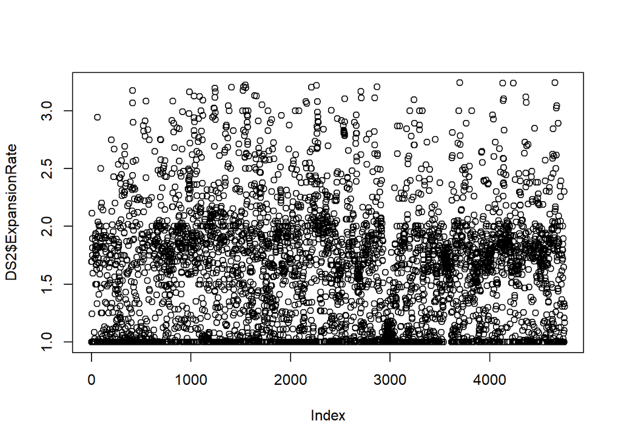

```r
DS2 <- subset(DS1, DS1$ExpansionRate < 3.25)
plot(DS2$ExpansionRate)
```

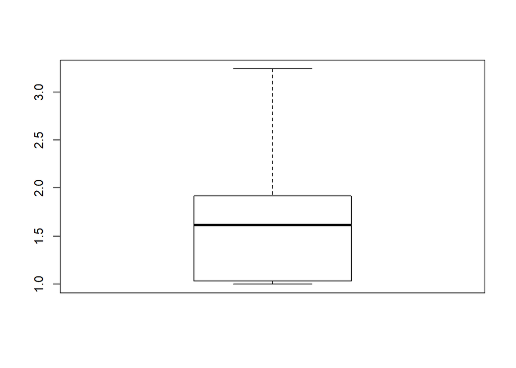

```r
boxplot(DS2$ExpansionRate)
```

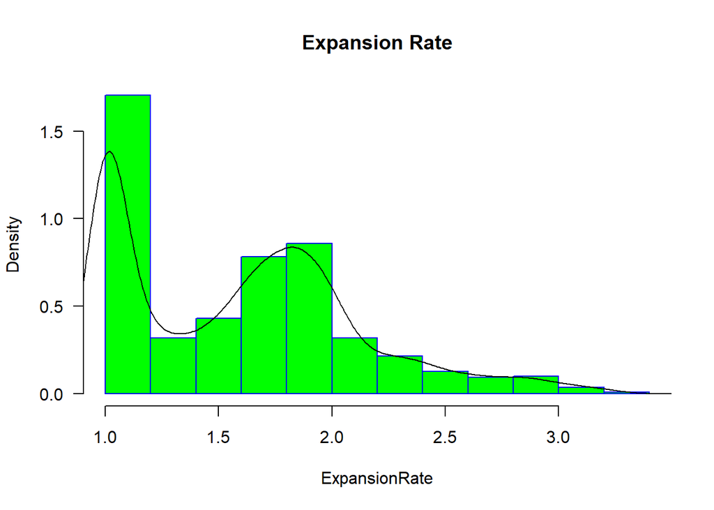

```r
hist(DS2$ExpansionRate,
     main="Expansion Rate",
     xlab="ExpansionRate",
     border="blue",
     col="green",
     las=1,
     prob = TRUE)
lines(density(DS2$ExpansionRate))
```

```r
print(summary(DS2$ExpansionRate))
```

```
##    Min. 1st Qu.  Median    Mean 3rd Qu.    Max.
##   1.000   1.032   1.613   1.592   1.918   3.240
```

#### Trimming Summary

From cutting the outliers with data expansion rates above 3.25, the observed number of records has been reduced from 4,916 to 4,752 (difference of 164), which is acceptable.

### Level of Extraction:

#### Outlier Identification

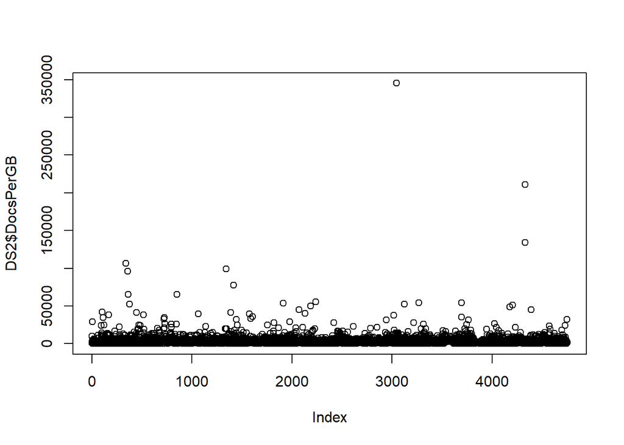

```r
plot(DS2$DocsPerGB)
```

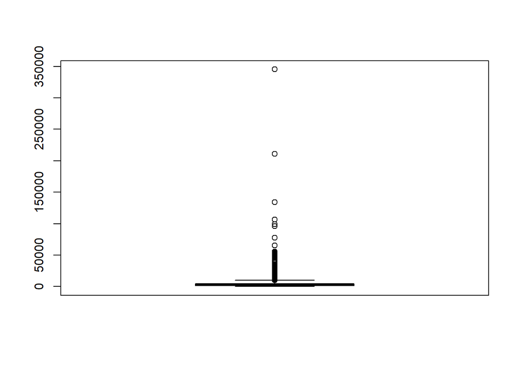

```r
boxplot(DS2$DocsPerGB)
```

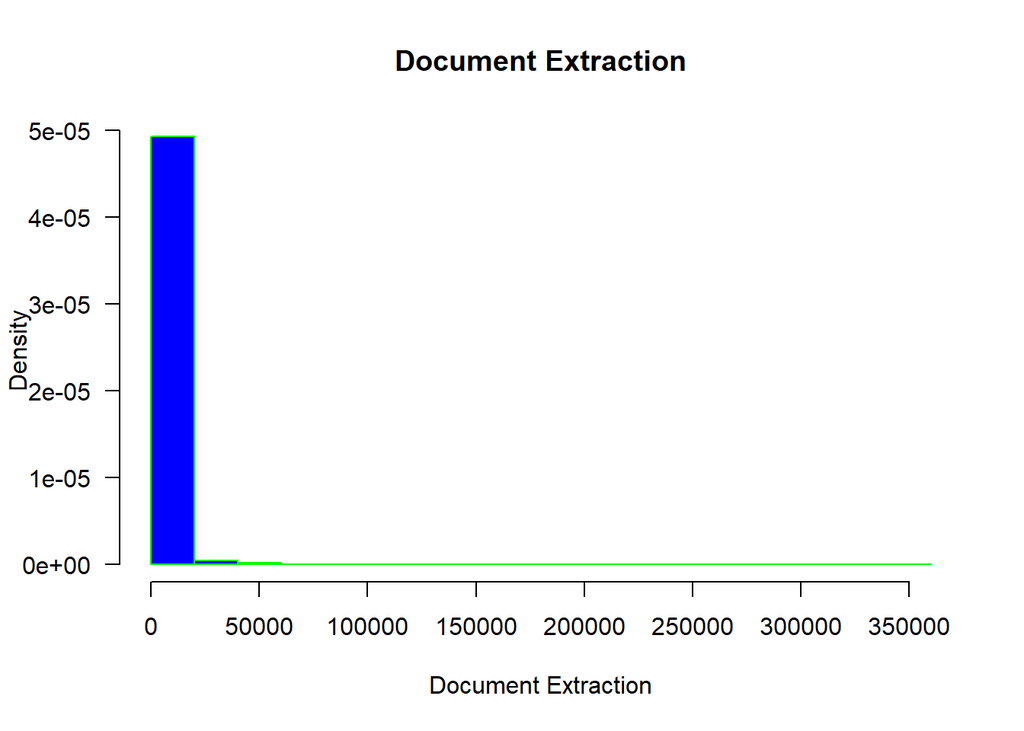

```r
hist(DS2$DocsPerGB,
     main="Document Extraction",
     xlab="Document Extraction",
     border="green",
     col="blue",
     las=1,
     prob = TRUE)
lines(density(DS2$ExpansionRate))
```

```r
summary(DS2$DocsPerGB)
```

```
##     Min.  1st Qu.   Median     Mean  3rd Qu.     Max.
##      0.3   1178.1   2597.1   3969.2   4578.7 345312.5
```

#### Trimming Outliers

From the initial investigation into the outliers in documents per gigabyte(“level of extraction”) from information received from CTO, there appear to be some significant outliers, as the max is 345,312.5, however, 75% fo the observations are below 4,578.8. The improve the quality of the analysis, I have determined to create a subset of the data to work with removing the outliers. To create the subset, I will create a new dataset (“DS3”) I am setting the documents per gigabyte threshold at 8,000.

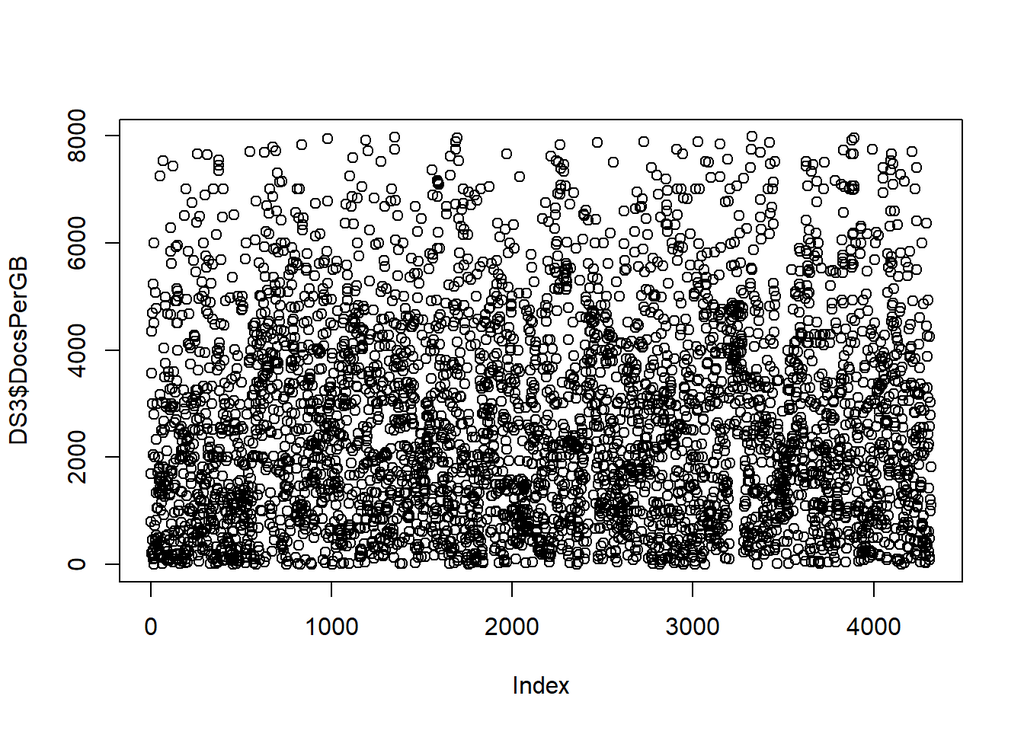

```r
DS3 <- subset(DS2, DS2$DocsPerGB < 8000)
plot(DS3$DocsPerGB)
```

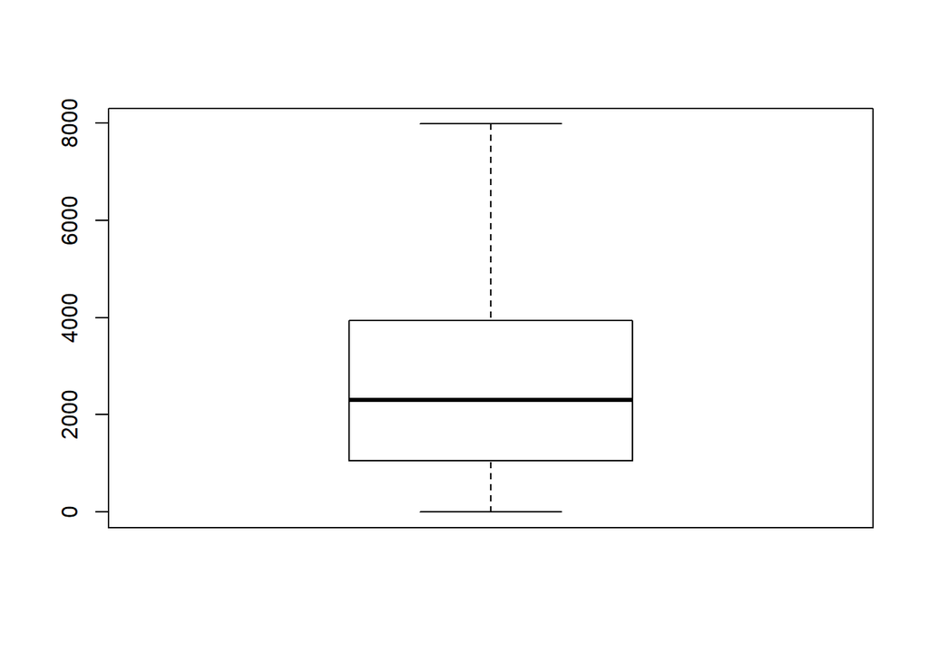

```r
boxplot(DS3$DocsPerGB)
```

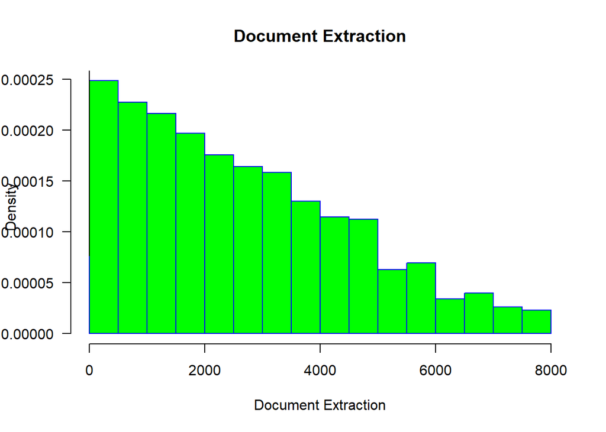

```r
hist(DS3$DocsPerGB,
     main="Document Extraction",
     xlab="Document Extraction",
     border="blue",
     col="green",
     las=1,
     prob = TRUE)
lines(density(DS3$ExpansionRate))
```

```r
summary(DS3$DocsPerGB)
```

```
##     Min.  1st Qu.   Median     Mean  3rd Qu.     Max.
##    0.333 1052.632 2307.692 2655.701 3943.969 7980.583
```

## Evaluation Model

### Naive Model

To create the first nieve model that will be used as a base for determining the success of this project as specified in the “FPS” I retrieve the mean for the Expansion Rate.

```r
"Mean"
```

```
## [1] "Mean"
```

```r
mean(DS3$ExpansionRate)
```

```
## [1] 1.59977
```

```r
"Standard Deviation"
```

```
## [1] "Standard Deviation"
```

```r
sd(DS3$ExpansionRate)
```

```
## [1] 0.5230665
```

## Root Squared

```r
actual <- c(DS3$ExpansionRate * DS3$GBPreExp)
predicted <- c(mean(DS3$ExpansionRate) * DS3$GBPreExp)
R2 <- 1 - (sum((actual-predicted)^2)/sum((actual-mean(actual))^2))
R2
```

```
## [1] 0.9065481
```

## Root Mean Squared Error(“RMSE”)

```r
library(Metrics)
rmse(actual, predicted)
```

```
## [1] 5.850839
```

## Confusion Matrix

Once I have developed a linear regression model, I will create a confusion matrix to determine if the linear regression model gives more accurate results compared to using the naive/mean model +/- 1/3 the standard deviation. [See Assignment 3]

[figure not shown]